# Розділ 3 Лабораторна робота №2. Маніпулювання даними

[Daniil Tereshchenko](https://www.linkedin.com/in/daniil-tereshchenko/), 2022

2022-09-24

# Імпорт даних

```r
#install_formats()
library(rio)
df <- data.frame(x = 1:5, y = rnorm(5))
export(df, "data/df_data_frame.txt")
dfImp <- import("data/df_data_frame.txt")
dfImp
```

|  | x | y |
| --- | --- | --- |
| 1 | 1 | -1.55443583 |
| 2 | 2 | 0.25382158 |
| 3 | 3 | -0.76505959 |
| 4 | 4 | 0.21443802 |
| 5 | 5 | 0.03632705 |

```r
data("mtcars") #підключення стандартного набору даних mtcars
# head(mtcars)
export(head(mtcars), "data/mtcars.dta")
convert('data/mtcars.dta', 'data/mtcars.csv')
import("data/mtcars.csv")
```

|  | mpg | cyl | disp | hp | drat | wt | qsec | vs | am | gear | carb |
| --- | --- | --- | --- | --- | --- | --- | --- | --- | --- | --- | --- |
| 1 | 21.0 | 6 | 160 | 110 | 3.90 | 2.620 | 16.46 | 0 | 1 | 4 | 4 |
| 2 | 21.0 | 6 | 160 | 110 | 3.90 | 2.875 | 17.02 | 0 | 1 | 4 | 4 |
| 3 | 22.8 | 4 | 108 | 93 | 3.85 | 2.320 | 18.61 | 1 | 1 | 4 | 1 |
| 4 | 21.4 | 6 | 258 | 110 | 3.08 | 3.215 | 19.44 | 1 | 0 | 3 | 1 |
| 5 | 18.7 | 8 | 360 | 175 | 3.15 | 3.440 | 17.02 | 0 | 0 | 3 | 2 |
| 6 | 18.1 | 6 | 225 | 105 | 2.76 | 3.460 | 20.22 | 1 | 0 | 3 | 1 |

## Імпорт з реляційних баз даних

```r
#install.packages("dbplyr")
library(dbplyr)
library(dplyr)
#install.packages("RSQLite")
library(RSQLite)

#my_db <- src_sqlite("data/my_db.sqlite3", create = T)
```

```r
#install.packages("nycflights13")
library(nycflights13)
# flights_sqlite <- copy_to(my_db, flights, temporary = FALSE,
#                           indexes = list(c("year", "month", "day"), "carrier", "tailnum"))
# head(flights_sqlite)
```

```r
con <- DBI::dbConnect(RSQLite::SQLite(), path = "data/my_db.sqlite3")
flights_sqlite <- copy_to(con, nycflights13::flights, "flights",
        temporary = FALSE,
        indexes = list(
          c("year", "month", "day"),
          "carrier",
          "tailnum",
          "dest"
        )
)

head(flights_sqlite)
```

| year | month | day | dep_time | sched_dep_time | dep_delay | arr_time | sched_arr_time | arr_delay | carrier | flight | tailnum | origin | dest | air_time | distance | hour | minute | time_hour |
| --- | --- | --- | --- | --- | --- | --- | --- | --- | --- | --- | --- | --- | --- | --- | --- | --- | --- | --- |
| 2013 | 1 | 1 | 517 | 515 | 2 | 830 | 819 | 11 | UA | 1545 | N14228 | EWR | IAH | 227 | 1400 | 5 | 15 | 1357034400 |
| 2013 | 1 | 1 | 533 | 529 | 4 | 850 | 830 | 20 | UA | 1714 | N24211 | LGA | IAH | 227 | 1416 | 5 | 29 | 1357034400 |
| 2013 | 1 | 1 | 542 | 540 | 2 | 923 | 850 | 33 | AA | 1141 | N619AA | JFK | MIA | 160 | 1089 | 5 | 40 | 1357034400 |
| 2013 | 1 | 1 | 544 | 545 | -1 | 1004 | 1022 | -18 | B6 | 725 | N804JB | JFK | BQN | 183 | 1576 | 5 | 45 | 1357034400 |
| 2013 | 1 | 1 | 554 | 600 | -6 | 812 | 837 | -25 | DL | 461 | N668DN | LGA | ATL | 116 | 762 | 6 | 0 | 1357038000 |
| 2013 | 1 | 1 | 554 | 558 | -4 | 740 | 728 | 12 | UA | 1696 | N39463 | EWR | ORD | 150 | 719 | 5 | 58 | 1357034400 |

```r
DBI::dbDisconnect(con)
```

# Приведення даних до охайного вигляду

```r
#install.packages("tidyverse")
library(tidyverse)
```

```r
table1 %>%
  mutate(rate = cases / population * 10000)
```

| country | year | cases | population | rate |
| --- | --- | --- | --- | --- |
| Afghanistan | 1999 | 745 | 19987071 | 0.372741 |
| Afghanistan | 2000 | 2666 | 20595360 | 1.294466 |
| Brazil | 1999 | 37737 | 172006362 | 2.193930 |
| Brazil | 2000 | 80488 | 174504898 | 4.612363 |
| China | 1999 | 212258 | 1272915272 | 1.667495 |
| China | 2000 | 213766 | 1280428583 | 1.669488 |

```r
table1 %>%
  count(year, wt = cases)
```

| year | n |
| --- | --- |
| 1999 | 250740 |
| 2000 | 296920 |

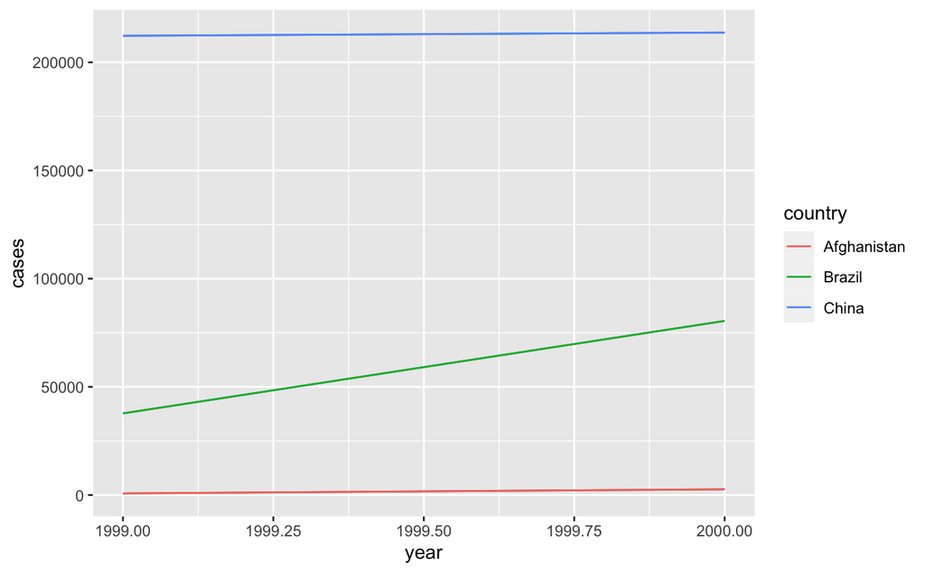

```r
library(ggplot2)
ggplot(table1, aes(year, cases)) +
    geom_line(aes(group = country), colour = "grey50") +
    geom_line(aes(colour = country))
```

## Завдання на самостійну роботу. Побудувати динаміку відносного критерію rate кількості захворювань по роках для кожної держави.

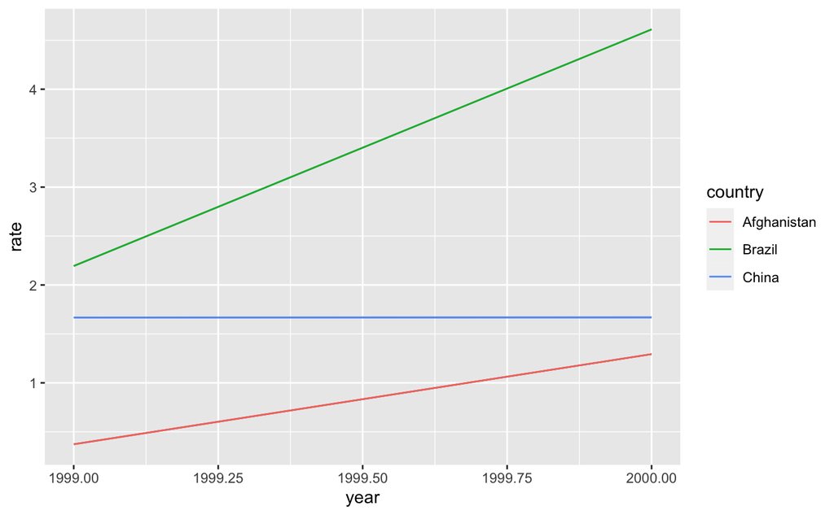

```r
table1 %>%
  mutate(rate = cases / population * 10000) %>%
  ggplot(aes(year, rate)) +
  geom_line(aes(group = country), colour = "grey50") +
  geom_line(aes(colour = country))
```

## Процедури Separating і Uniting

|  | country | year | rate |
| --- | --- | --- | --- |
| 1 | Afghanistan | 1999 | 745/19987071 |
| 2 | Afghanistan | 2000 | 2666/20595360 |
| 3 | Brazil | 1999 | 37737/172006362 |
| 4 | Brazil | 2000 | 80488/174504898 |
| 5 | China | 1999 | 212258/1272915272 |
| 6 | China | 2000 | 213766/1280428583 |

```r
table3 %>%
  separate(rate, into = c("cases", "population"))
```

| country | year | cases | population |
| --- | --- | --- | --- |
| Afghanistan | 1999 | 745 | 19987071 |
| Afghanistan | 2000 | 2666 | 20595360 |
| Brazil | 1999 | 37737 | 172006362 |
| Brazil | 2000 | 80488 | 174504898 |
| China | 1999 | 212258 | 1272915272 |
| China | 2000 | 213766 | 1280428583 |

|  | country | century | year | rate |
| --- | --- | --- | --- | --- |
| 1 | Afghanistan | 19 | 99 | 745/19987071 |
| 2 | Afghanistan | 20 | 00 | 2666/20595360 |
| 3 | Brazil | 19 | 99 | 37737/172006362 |
| 4 | Brazil | 20 | 00 | 80488/174504898 |
| 5 | China | 19 | 99 | 212258/1272915272 |
| 6 | China | 20 | 00 | 213766/1280428583 |

```r
table5 %>%
    unite(new, century, year, sep = "")
```

| country | new | rate |
| --- | --- | --- |
| Afghanistan | 1999 | 745/19987071 |
| Afghanistan | 2000 | 2666/20595360 |
| Brazil | 1999 | 37737/172006362 |
| Brazil | 2000 | 80488/174504898 |
| China | 1999 | 212258/1272915272 |
| China | 2000 | 213766/1280428583 |

## Пропущені значення

```r
stocks <- tibble(
  year = c(2015, 2015, 2015, 2015, 2016, 2016, 2016),
  qtr = c(1, 2, 3, 4, 2, 3, 4),
  return = c(1.88, 0.59, 0.35, NA, 0.92, 0.17, 2.66)
)
stocks
```

[output not shown]

```r
stocks %>%
  spread(year, return)
```

| qtr | 2015 | 2016 |
| --- | --- | --- |
| 1 | 1.88 | NA |
| 2 | 0.59 | 0.92 |
| 3 | 0.35 | 0.17 |
| 4 | NA | 2.66 |

```r
stocks %>%
  complete(year, qtr)
```

| year | qtr | return |
| --- | --- | --- |
| 2015 | 1 | 1.88 |
| 2015 | 2 | 0.59 |
| 2015 | 3 | 0.35 |
| 2015 | 4 | NA |
| 2016 | 1 | NA |
| 2016 | 2 | 0.92 |
| 2016 | 3 | 0.17 |
| 2016 | 4 | 2.66 |

```r
stocks %>%
  spread(year, return) %>%
    gather(year, return, '2015':'2016', na.rm = TRUE)
```

| qtr | year | return |
| --- | --- | --- |
| 1 | 2015 | 1.88 |
| 2 | 2015 | 0.59 |
| 3 | 2015 | 0.35 |
| 2 | 2016 | 0.92 |
| 3 | 2016 | 0.17 |
| 4 | 2016 | 2.66 |

```r
df <- data.frame(Month = 1:12, Year = c(2000, rep(NA,11)))
df
```

| Month | Year |
| --- | --- |
| 1 | 2000 |
| 2 | NA |
| 3 | NA |
| 4 | NA |
| 5 | NA |
| 6 | NA |
| 7 | NA |
| 8 | NA |
| 9 | NA |
| 10 | NA |

[output cut: 2 more lines]

```r
df %>%
  fill(Year)
```

| Month | Year |
| --- | --- |
| 1 | 2000 |
| 2 | 2000 |
| 3 | 2000 |
| 4 | 2000 |
| 5 | 2000 |
| 6 | 2000 |
| 7 | 2000 |
| 8 | 2000 |
| 9 | 2000 |
| 10 | 2000 |

[output cut: 2 more lines]

## Трансформація

```r
library(dplyr)

starwars %>%
  filter(species == "Droid")
```

| name | height | mass | hair_color | skin_color | eye_color | birth_year | sex | gender | homeworld | species | films | vehicles | starships |
| --- | --- | --- | --- | --- | --- | --- | --- | --- | --- | --- | --- | --- | --- |
| C-3PO | 167 | 75 | NA | gold | yellow | 112 | none | masculine | Tatooine | Droid |  |  |  |
| R2-D2 | 96 | 32 | NA | white, blue | red | 33 | none | masculine | Naboo | Droid |  |  |  |
| R5-D4 | 97 | 32 | NA | white, red | red | NA | none | masculine | Tatooine | Droid |  |  |  |
| IG-88 | 200 | 140 | none | metal | red | 15 | none | masculine | NA | Droid |  |  |  |
| R4-P17 | 96 | NA | none | silver, red | red, blue | NA | none | feminine | NA | Droid |  |  |  |
| BB8 | NA | NA | none | none | black | NA | none | masculine | NA | Droid |  |  |  |

```r
starwars %>%
  select(name, ends_with("color"))
```

| name | hair_color | skin_color | eye_color |
| --- | --- | --- | --- |
| Luke Skywalker | blond | fair | blue |
| C-3PO | NA | gold | yellow |
| R2-D2 | NA | white, blue | red |
| Darth Vader | none | white | yellow |
| Leia Organa | brown | light | brown |
| Owen Lars | brown, grey | light | blue |
| Beru Whitesun lars | brown | light | blue |
| R5-D4 | NA | white, red | red |
| Biggs Darklighter | black | light | brown |
| Obi-Wan Kenobi | auburn, white | fair | blue-gray |

[output cut: 77 more lines]

```r
starwars %>%
  mutate(name, bmi = mass / ((height / 100) ^ 2 )) %>%
    select(name:mass, bmi)
```

| name | height | mass | bmi |
| --- | --- | --- | --- |
| Luke Skywalker | 172 | 77.0 | 26.02758 |
| C-3PO | 167 | 75.0 | 26.89232 |
| R2-D2 | 96 | 32.0 | 34.72222 |
| Darth Vader | 202 | 136.0 | 33.33007 |
| Leia Organa | 150 | 49.0 | 21.77778 |
| Owen Lars | 178 | 120.0 | 37.87401 |
| Beru Whitesun lars | 165 | 75.0 | 27.54821 |
| R5-D4 | 97 | 32.0 | 34.00999 |
| Biggs Darklighter | 183 | 84.0 | 25.08286 |
| Obi-Wan Kenobi | 182 | 77.0 | 23.24598 |

[output cut: 77 more lines]

| name | height | mass | hair_color | skin_color | eye_color | birth_year | sex | gender | homeworld | species | films | vehicles | starships |
| --- | --- | --- | --- | --- | --- | --- | --- | --- | --- | --- | --- | --- | --- |
| Jabba Desilijic Tiure | 175 | 1358.0 | NA | green-tan, brown | orange | 600.0 | hermaphroditic | masculine | Nal Hutta | Hutt |  |  |  |
| Grievous | 216 | 159.0 | none | brown, white | green, yellow | NA | male | masculine | Kalee | Kaleesh |  |  |  |
| IG-88 | 200 | 140.0 | none | metal | red | 15.0 | none | masculine | NA | Droid |  |  |  |
| Darth Vader | 202 | 136.0 | none | white | yellow | 41.9 | male | masculine | Tatooine | Human |  |  |  |
| Tarfful | 234 | 136.0 | brown | brown | blue | NA | male | masculine | Kashyyyk | Wookiee |  |  |  |
| Owen Lars | 178 | 120.0 | brown, grey | light | blue | 52.0 | male | masculine | Tatooine | Human |  |  |  |
| Bossk | 190 | 113.0 | none | green | red | 53.0 | male | masculine | Trandosha | Trandoshan |  |  |  |
| Chewbacca | 228 | 112.0 | brown | unknown | blue | 200.0 | male | masculine | Kashyyyk | Wookiee |  |  |  |
| Jek Tono Porkins | 180 | 110.0 | brown | fair | blue | NA | male | masculine | Bestine IV | Human |  |  |  |
| Dexter Jettster | 198 | 102.0 | none | brown | yellow | NA | male | masculine | Ojom | Besalisk |  |  |  |

[output cut: 77 more lines]

```r
starwars %>%
  group_by(species) %>%
  summarize(
    n = n(),
    mass = mean(mass, na.rm = TRUE)
  ) %>%
  filter(n > 1)
```

| species | n | mass |
| --- | --- | --- |
| Droid | 6 | 69.75000 |
| Gungan | 3 | 74.00000 |
| Human | 35 | 82.78182 |
| Kaminoan | 2 | 88.00000 |
| Mirialan | 2 | 53.10000 |
| Twi'lek | 2 | 55.00000 |
| Wookiee | 2 | 124.00000 |
| Zabrak | 2 | 80.00000 |
| NA | 4 | 48.00000 |

# Приклад виконання індівідуального завдання

## Постановка задачі

Створити реляційну БД, використовуючи СУБД SQLite. Виконати експорт даних у БД зі стандартного набору nycflights13 щодо авіаперевезень аеропорту Нью-Йорк за 2013 рік.

Налаштувати індекси: (“year,” “month,” “day”), “carrier,” “tailnum,” “dest.” Підготувати RMarkdown-документ, який би давав можливість генерувати електронний звіт з результатами виконання наступних задач:

вибрати поля year:day, dep_delay, arr_delay з таблиці flights. вибрати всі рейси з часом затримки (dep_delay) більше ніж 240 хв. Обчислити середній час затримки вильоту (dep_time) з попереднім групуванням по відстані авіамаршруту (dest). Обчислити для кожного бортового номеру літака з кількістю рейсів більше 100 середній час затримки прибуття та кількість рейсів; дані впорядкувати за убуванням часу затримки прибуття. розділити набір даних по літаках і розрахувати кількість вильотів і середню дальність польоту і затримку прибуття; побудувати графік залежності середньої затримки від середньої дальності польоту (за допомогою ggplot2). знайти кількість літаків і кількість вильотів в усі можливі пункти призначення.

## Виконання завдання

```r
my_db <- src_sqlite("data/my_db.sqlite3", create = T)
```

```r
con <- DBI::dbConnect(RSQLite::SQLite(), path = "data/my_db.sqlite3")
flights_sqlite <- copy_to(con, nycflights13::flights, "flights",
        temporary = FALSE,
        indexes = list(
          c("year", "month", "day"),
          "carrier",
          "tailnum",
          "dest"
        )
)

head(flights_sqlite)
```

| year | month | day | dep_time | sched_dep_time | dep_delay | arr_time | sched_arr_time | arr_delay | carrier | flight | tailnum | origin | dest | air_time | distance | hour | minute | time_hour |
| --- | --- | --- | --- | --- | --- | --- | --- | --- | --- | --- | --- | --- | --- | --- | --- | --- | --- | --- |
| 2013 | 1 | 1 | 517 | 515 | 2 | 830 | 819 | 11 | UA | 1545 | N14228 | EWR | IAH | 227 | 1400 | 5 | 15 | 1357034400 |
| 2013 | 1 | 1 | 533 | 529 | 4 | 850 | 830 | 20 | UA | 1714 | N24211 | LGA | IAH | 227 | 1416 | 5 | 29 | 1357034400 |
| 2013 | 1 | 1 | 542 | 540 | 2 | 923 | 850 | 33 | AA | 1141 | N619AA | JFK | MIA | 160 | 1089 | 5 | 40 | 1357034400 |
| 2013 | 1 | 1 | 544 | 545 | -1 | 1004 | 1022 | -18 | B6 | 725 | N804JB | JFK | BQN | 183 | 1576 | 5 | 45 | 1357034400 |
| 2013 | 1 | 1 | 554 | 600 | -6 | 812 | 837 | -25 | DL | 461 | N668DN | LGA | ATL | 116 | 762 | 6 | 0 | 1357038000 |
| 2013 | 1 | 1 | 554 | 558 | -4 | 740 | 728 | 12 | UA | 1696 | N39463 | EWR | ORD | 150 | 719 | 5 | 58 | 1357034400 |

```r
flights_sqlite %>% select(year:day, dep_delay, arr_delay)
```

| year | month | day | dep_delay | arr_delay |
| --- | --- | --- | --- | --- |
| 2013 | 1 | 1 | 2 | 11 |
| 2013 | 1 | 1 | 4 | 20 |
| 2013 | 1 | 1 | 2 | 33 |
| 2013 | 1 | 1 | -1 | -18 |
| 2013 | 1 | 1 | -6 | -25 |
| 2013 | 1 | 1 | -4 | 12 |
| 2013 | 1 | 1 | -5 | 19 |
| 2013 | 1 | 1 | -3 | -14 |
| 2013 | 1 | 1 | -3 | -8 |
| 2013 | 1 | 1 | -2 | 8 |

[output cut: 990 more lines]

```r
flights_sqlite %>% filter(dep_delay > 240)
```

| year | month | day | dep_time | sched_dep_time | dep_delay | arr_time | sched_arr_time | arr_delay | carrier | flight | tailnum | origin | dest | air_time | distance | hour | minute | time_hour |
| --- | --- | --- | --- | --- | --- | --- | --- | --- | --- | --- | --- | --- | --- | --- | --- | --- | --- | --- |
| 2013 | 1 | 1 | 848 | 1835 | 853 | 1001 | 1950 | 851 | MQ | 3944 | N942MQ | JFK | BWI | 41 | 184 | 18 | 35 | 1357081200 |
| 2013 | 1 | 1 | 1815 | 1325 | 290 | 2120 | 1542 | 338 | EV | 4417 | N17185 | EWR | OMA | 213 | 1134 | 13 | 25 | 1357063200 |
| 2013 | 1 | 1 | 1842 | 1422 | 260 | 1958 | 1535 | 263 | EV | 4633 | N18120 | EWR | BTV | 46 | 266 | 14 | 22 | 1357066800 |
| 2013 | 1 | 1 | 2115 | 1700 | 255 | 2330 | 1920 | 250 | 9E | 3347 | N924XJ | JFK | CVG | 115 | 589 | 17 | 0 | 1357077600 |
| 2013 | 1 | 1 | 2205 | 1720 | 285 | 46 | 2040 | 246 | AA | 1999 | N5DNAA | EWR | MIA | 146 | 1085 | 17 | 20 | 1357077600 |
| 2013 | 1 | 1 | 2343 | 1724 | 379 | 314 | 1938 | 456 | EV | 4321 | N21197 | EWR | MCI | 222 | 1092 | 17 | 24 | 1357077600 |
| 2013 | 1 | 2 | 1332 | 904 | 268 | 1616 | 1128 | 288 | EV | 4364 | N41104 | EWR | MCI | 203 | 1092 | 9 | 4 | 1357135200 |
| 2013 | 1 | 2 | 1412 | 838 | 334 | 1710 | 1147 | 323 | UA | 468 | N474UA | EWR | MCO | 150 | 937 | 8 | 38 | 1357131600 |
| 2013 | 1 | 2 | 1607 | 1030 | 337 | 2003 | 1355 | 368 | AA | 179 | N324AA | JFK | SFO | 346 | 2586 | 10 | 30 | 1357138800 |
| 2013 | 1 | 2 | 2131 | 1512 | 379 | 2340 | 1741 | 359 | UA | 488 | N593UA | LGA | DEN | 228 | 1620 | 15 | 12 | 1357156800 |

[output cut: 990 more lines]

```r
flights_sqlite %>%
  group_by(dest) %>%
  summarise(delay = mean(dep_time))
```

| dest | delay |
| --- | --- |
| ABQ | 2005.7323 |
| ACK | 1032.6642 |
| ALB | 1627.1885 |
| ANC | 1635.3750 |
| ATL | 1293.2914 |
| AUS | 1521.4764 |
| AVL | 1174.7643 |
| BDL | 1490.3107 |
| BGR | 1689.7167 |
| BHM | 1943.6397 |

[output cut: 95 more lines]

```r
tailnum_delay_sqlite <- flights_sqlite %>%
  group_by(tailnum) %>%
  summarise(
    delay = mean(arr_delay),
    n = n()
  ) %>%
  arrange(desc(delay)) %>%
  filter(n > 100)
tailnum_delay_sqlite
```

| tailnum | delay | n |
| --- | --- | --- |
| NA | NA | 2512 |
| N0EGMQ | 9.982954545 | 371 |
| N10156 | 12.717241379 | 153 |
| N10575 | 20.691449814 | 289 |
| N11106 | 14.880952381 | 129 |
| N11107 | 15.014388489 | 148 |
| N11109 | 14.851063830 | 148 |
| N11113 | 15.761904762 | 138 |
| N11119 | 30.306569343 | 148 |
| N11121 | 10.306122449 | 154 |

[output cut: 990 more lines]

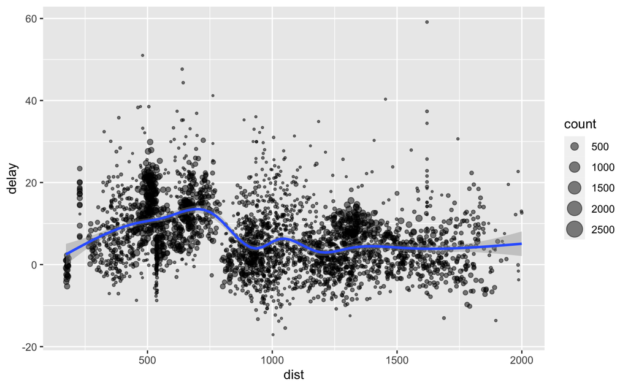

```r
#Розділяємо набір даних по літаках і розрахувати кількість вильотів і середню дальність польоту і затримку прибуття; будуємо графік залежності середньої затримки від середньої дальності польоту
library(ggplot2)
planes <- group_by(flights, tailnum)
delay <- summarise(planes,
            count = n(),
            dist = mean(distance, na.rm = TRUE),
            delay = mean(arr_delay, na.rm = TRUE))
delay <- filter(delay, count > 20, dist < 2000)

ggplot(delay, aes(dist, delay)) +
  geom_point(aes(size = count), alpha = 1/2) +
  geom_smooth() +
  scale_size_area()
```

```r
#Знаходимо кількість літаків і кількість вильотів в усі можливі пункти призначення
destinations <- group_by(flights, dest)
summarise(destinations,
  planes = n_distinct(tailnum),
  flights = n()
)
```

[output not shown]

```r
DBI::dbDisconnect(con)
```